# WeRateDogs Project

### Visualizing Data - Most Rated Dog Breeds

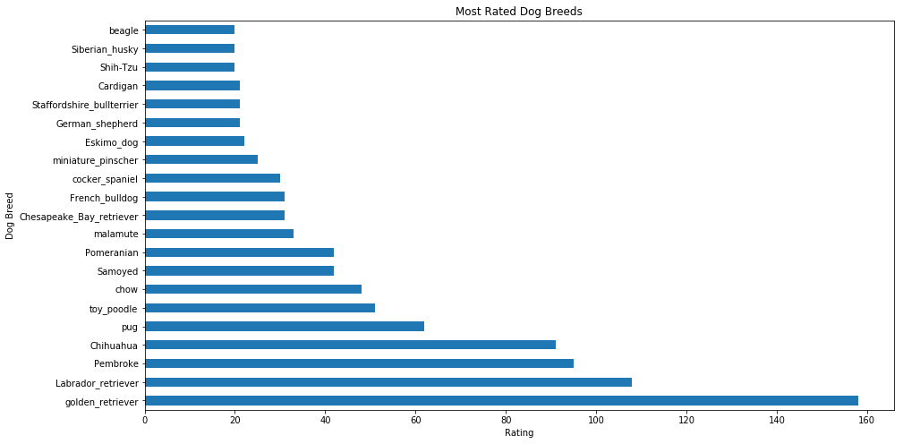

```python
# generate graph to show the top 20 breeds with the most ratings
df_by_breed = df_clean.groupby('dog_breed').filter(lambda x: len(x) >= 20)
df_by_breed['dog_breed'].value_counts().plot(kind = 'barh')
plt.title('Most Rated Dog Breeds')
plt.xlabel('Rating')
plt.ylabel('Dog Breed')
```

**Observation**:

1. No surprise there! Golden Retrievers are the best in my personal opinion
2. Golden Retrievers have a big advantage over all other breeds.
3. Its surprising to find that Siberian Huskies are not rated as often. Perhaps one reason is because Huskies require a lot of maintenance since these dogs are typically of cold regions and tend to shed a lot of hair.

### Visualizing Data - Visualize Rating System Over Time

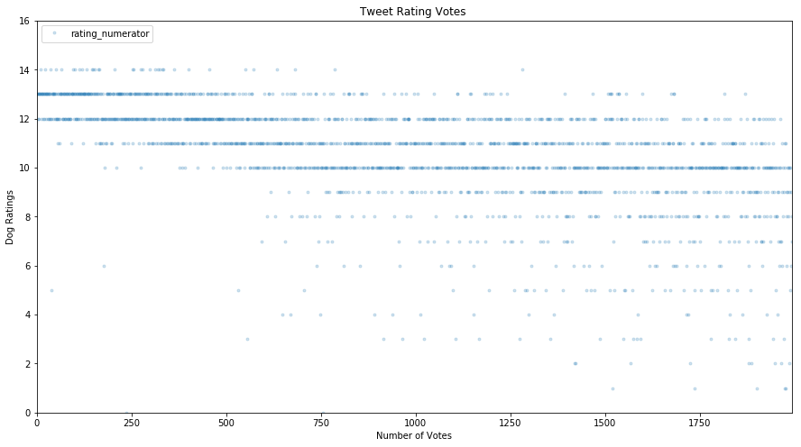

```python
# https://pandas.pydata.org/pandas-docs/stable/reference/api/pandas.DataFrame.plot.html
# Next we will visuallize thee rating system
df_clean.plot(y ='rating_numerator', ylim=[0,16], style = '.', alpha = .2)
plt.xlabel('Number of Votes')
plt.ylabel('Dog Ratings')
plt.title('Tweet Rating Votes ')
```

```python
# Now lets look at the rating_numerator using describe() function
# https://pandas.pydata.org/pandas-docs/stable/reference/api/pandas.DataFrame.describe.html
df_clean[df_clean['rating_numerator'] <= 14]['rating_numerator'].describe()
```

```
count    1975.000000
mean       10.538228
std         2.200311
min         0.000000
25%        10.000000
50%        11.000000
75%        12.000000
max        14.000000
Name: rating_numerator, dtype: float64
```

### Visualizing Data - Most populate Dog Gender

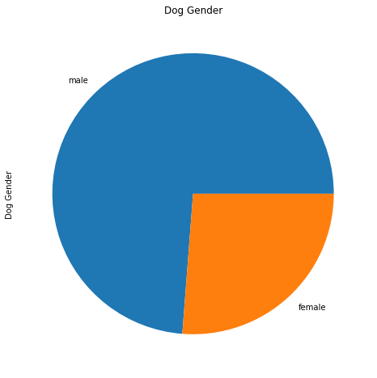

```python
# Plot gender into a pie chart ignoring the null values and concentrating only the male and female values
df_clean[df_clean['dog_gender'].notnull()]['dog_gender'].value_counts().plot(kind = 'pie')
plt.title('Dog Gender')
plt.ylabel('Dog Gender')
```

#### Observations:

1. Males are the most popular gender

### Visualizing Data - Trends of Number of Tweets posted vs Dates

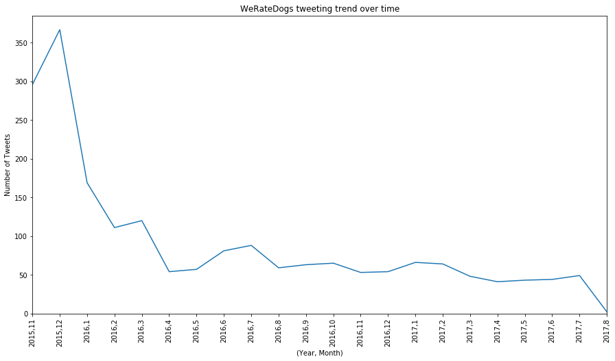

```python
data = df_clean.tweet_id.groupby([df_clean["tweet_date"].dt.year, df_clean["tweet_date"].dt.month]).count()
ax = data.plot('line', title='WeRateDogs tweeting trend over time')
ax.set_xlabel("(Year, Month)")
ax.set_ylabel("Number of Tweets")
ax.set_ylim(0, )
plt.xticks(range(len(data.index)), data.index.map('{0[0]},{0[1]}'.format), rotation=90)
plt.savefig('tweet_trend')
```

```python
df_clean.info()
```

```
<class 'pandas.core.frame.DataFrame'>
RangeIndex: 1994 entries, 0 to 1993
Data columns (total 16 columns):
tweet_id                   1994 non-null object
tweet_date                 1994 non-null datetime64[ns, UTC]
tweet_source               1994 non-null category
tweet_text                 1994 non-null object
tweet_url                  1994 non-null object
rating_numerator           1994 non-null float64
rating_denominator         1994 non-null float64
tweet_picture_predicted    1994 non-null object
tweet_favorites            1990 non-null float64
tweet_retweets             1990 non-null float64
user_followers             1990 non-null float64
dog_stage                  306 non-null category
dog_breed                  1686 non-null object
confidence_level           1994 non-null float64
dog_name                   23 non-null object
dog_gender                 862 non-null category
dtypes: category(3), datetime64[ns, UTC](1), float64(6), object(6)
memory usage: 209.0+ KB
```

### Visualizing Data - Tweet sources

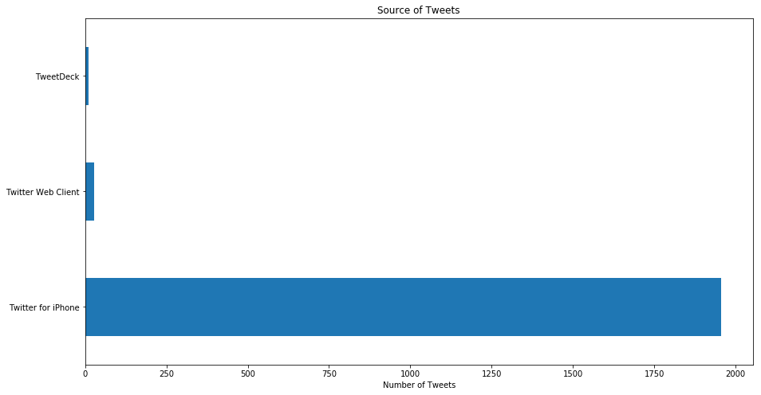

```python
# graph the sources of tweets
df_clean['tweet_source'].value_counts().plot('barh', title='Source of Tweets').set_xlabel("Number of Tweets")
plt.savefig('tweet_source')
```

#### Observations:

1. The majority of tweets are from iphones.

## Part V- Reporting

Go Back To The Top

## Conclusions

Go Back To The Top

This was a challenging project for me but I learned alot. I had played with the Twitter API before but never at this level.

I had fun analyzing the data because the Twitter account WeRateDogs(@dog_rates) is dedicated to dog reviews. In all the data you see many people engaging with each other because they share a common love for dogs. Seeing how much fun these dog owners are having with their pets makes me think about adopting a dog for my family, but its adopting a pet is a long term commitment with alot of responsibilities.

## Resources

Go Back To The Top

- [tweepy Download/Installation](https://pypi.org/project/tweepy/)
- [Twitter Developers](https://developer.twitter.com)
- [Pandas:Python Data Analysis Library](https://pandas.pydata.org)
- [Stackoverflow](https://stackoverflow.com)
- [Towards Data Science](https://towardsdatascience.com/the-simplest-cleanest-method-for-tracking-a-for-loops-progress-and-expected-run-time-in-python-972675392b3)
- [Google](https://www.google.com)
- [Udacity](https://www.udacity.com)

Go Back To The Top